# mapMCDA: aperçu du package

2019-03-20

```r
require(sp)
require(raster)
require(rasterVis)
```

```r
require(mapMCDA)
```

# Introduction

Le package `mapMCDA` facilite la ponderation de plusieurs facteurs de risque pour produîre une carte de risque épidémiologique.

Néanmoins, l’expertise de l’utilisateur est cruciale. Elle s’exprime à trois niveaux :

1. Choix des facteurs de risque rélevants
2. Pour chaque facteur, mise en échelle commune de risque (e.g. entre 0 et 100)
3. Évaluation deux-à-deux de l’importance rélative des facteurs de risque

À continuation, on utilise des cartes fournis par le package pour produîre une carte de risque d’exemple. **Cette carte n’a aucun valeur épidémiologique.**

# 1. Facteurs de risque

La fonction `mapMCDA_datasets()` permet de charger en mémoire toutes les cartes disponibles dans le package.

L’objet `cmr` est une simple liste de cartes : objets de type `Spatial*` pour les cartes vectoriels et de type `RasterLayer` pour les cartes raster.

Pour utiliser d’autre cartographie, utiliser les fonctions `rgdal::readOGR()` et `raster::raster()` respectivement pour des cartes vectoriels ou raster.

```r
cmr <- mapMCDA_datasets()

# layers <- list.files(
#   system.file("cartography/CMR", package = "mapMCDA"),
#   full.names = TRUE
# )
# cmr <- lapply(layers, load_layer)
# names(cmr) <- rmext(basename(layers)))
```

L’une de ces cartes est celle des unités épidémiologiques, utilisée pour établir le cadre de travail.

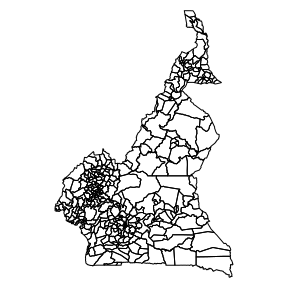

Unités épidémiologiques d’exemple pour le Cameroun.

```r
unites_epi <- cmr$cmr_admin3
par(mar = c(0, 0, 0, 0))
plot(unites_epi)
```

# 2. Mise en échelle

Chaque facteur de risque varie dans une échelle qui lui est propre. La densité animale, par exemple, varie entre 0 et presque 5500 têtes par $km^2$.

Pour les cartes *vectorielles*, qui representent la localisation des entités spatiales telles que lacs ou forêts, on considère la **distance** à dites entités.

Ce package utilise pour l’instant une fonction linèaire pour la mise en échelle. Cependant, la rélation peut être directe ou inverse.

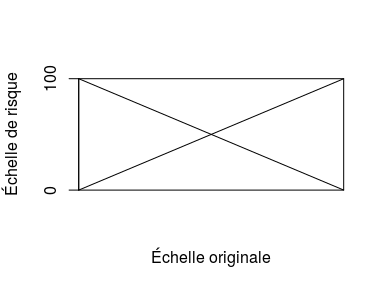

Mis en échelle directe ou inverse.

```r
plot(
  data.frame(x = c(0, 100), y = c(0, 100)),
  type = 'l',
  xaxs = "i",
  yaxs = "i",
  xaxt = "n",
  lab = c(1, 1, 7),
  xlab = c("Échelle originale"),
  ylab = c("Échelle de risque")
)
abline(100, -1)
```

La fonction `risk_layer()` calcule la carte de risque associé à un facteur concret dans une échelle donnée. Par défault c’est entre 0 et 100. Pour inverser la rélation il suffit de passer les limits dans l’ordre inverse, e.g. `c(100, 0)`.

D’ailleurs, elle utilise la carte d’unités épidémiologiques pour établir les limits de calcul de risque.

```r
risques <- list(
  dens_animale = risk_layer(
    cmr$animal.density,
    boundaries = unites_epi
    # , scale_target = c(0, 100)  # échelle directe par défault
  ),
  points_eau = risk_layer(
    cmr$water_bodies,
    boundaries = unites_epi,
    scale_target = c(100, 0)  # échelle renversée
  ),
  parcs = risk_layer(
    cmr$national_parks,
    boundaries = unites_epi,
    scale_target = c(100, 0)  # échelle renversée
  )
)
```

On voudrait examiner les cartes de risque ainsi calculées. Mais pour cela, il faut qu’elles soient *alignées*. C’est à dire, qu’elles aient les mêmes *extents*, *résolutions* et *projections*.

On peut se servir de la fonction `align_layers()` qui arrange tout ça pour nous. Noter que ce pas n’est pas nécessaire pour continuer, car cette fonction est automatiquement executée si besoin.

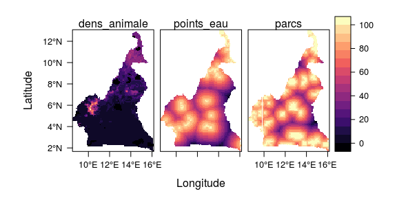

Niveaux de risque associé à chaque facteur.

```r
risques_alignes <- align_layers(risques)
levelplot(stack(risques_alignes))
```

# 3. Pondération des facteurs de risque

Il y a 3 facteurs à considérer. Il faut comparer 2-à-2 leurs importances relatives en une échelle de 1 à 9 et representer ces rélations en une matrice qui doit avoir des 1 dans son diagonale.

Noter que les élements symmetriques doivent être réciproques.

```r
M <- matrix(c(
  1,     6, 4,
  1/6,   1, 3,
  1/4, 1/3, 1
), byrow = TRUE, 3, 3)
colnames(M) <- rownames(M) <- names(risques)
knitr::kable(M, digits = 2)
```

|  | dens_animale | points_eau | parcs |
| --- | --- | --- | --- |
| dens_animale | 1.00 | 6.00 | 4 |
| points_eau | 0.17 | 1.00 | 3 |
| parcs | 0.25 | 0.33 | 1 |

Dans cette exemple, on considère que la densité animale est 6 fois plus importante que la distance aux points d’eau, et 4 fois plus importante que la distance aux parcs. Au même temps, que la distance aux points d’eau est 3 fois plus importante que celle aux parcs.

Le système calcule les coefficients de pondération les plus consistents avec ces valorations par paires, avec la fonction `compute_weights()`.

```r
w <- compute_weights(M)
```

[figure not shown]

Pondération des facteurs de risque.

# 4. Calcul de la carte de risque

La fonction `wlc()` (pour weighted linear combination) combine tous les facteurs de risque en utilisant les poids calculés précedament, et produise une carte de risque qui couvre toute la région.

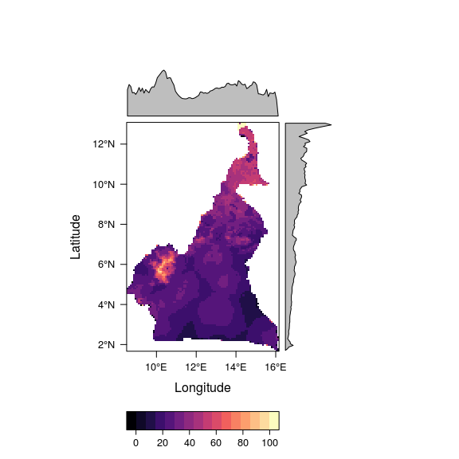

Carte de risque combiné.

```r
risque_combine <- wlc(risques, w)
levelplot(risque_combine)
```

Enfin, on peut produîre una carte par unité épidémiologique et dans une échelle de quelques niveaux de risque.

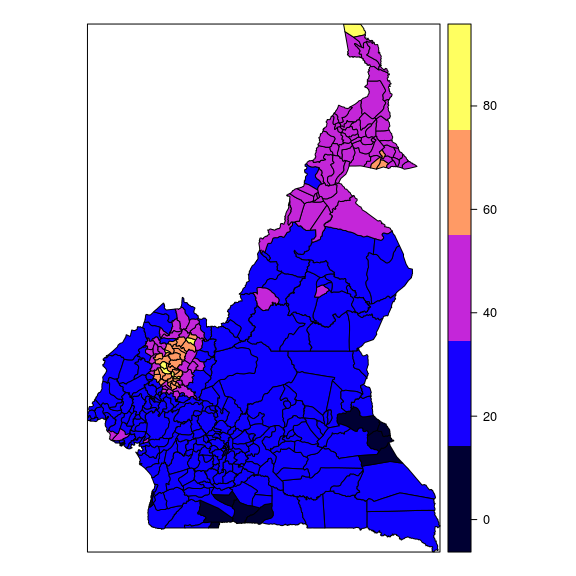

Carte de niveaux de risque par unité épidémiologique.

```r
risk_plot(unites_epi, risk_unit(risque_combine, unites_epi), n = 5)
```